# Residential relocation among older adults registered on housing company interest lists

Two linked papers from a prospective longitudinal study (Sweden, 2021–2024)

Published

August 27, 2026

**About this document**

This page presents two linked papers from a prospective longitudinal study of residential relocation among older adults registered on housing company interest lists in Sweden (N = 1,958; T1: 2021, T2: 2022, T3: 2024). Exact relocation dates are sourced from the Swedish tax register. Register data (income, marital status, employment, regional indicators) have been linked and are used in supplementary analyses; see Register-based analyses.

**Paper 1** examines how strongly moving intentions predict realized relocation and why many intenders do not follow through.  
**Paper 2** examines who relocates without intending to, and identifies the housing and structural factors that drive reactive, unplanned moves.

Jump to: Paper 1 · Paper 2 · Appendix: Full LPA

# Shared methods

## Study design and sample

**Design:** Prospective longitudinal survey study; three time points.

| Wave | Label | Year | n responded | Response rate |
| --- | --- | --- | --- | --- |
| T1 | Baseline | 2021 | 1,958 | 100% |
| T2 | First follow-up | 2022 | 1,501 | 76.7% |
| T3 | Second follow-up | 2024 | 1,296 | 66.2% |

Twenty-four participants died during the study period (10 between T1 and T2, 14 between T2 and T3). An additional 31 participants de-registered from the Swedish population register during the study period (15 between T1 and T2, 16 between T2 and T3), indicating emigration or administrative de-registration.

```
flowchart TD
    E["**Enrolled at T1 (2021)**<br/>n = 1,958"] --> T1
    T1["**T1 Baseline**<br/>N = 1,958 · 100%"] --> T2["**T2 First follow-up (2022)**<br/>N = 1,501 · 76.7%"]
    T1 --> D1["Lost to follow-up: n = 457<br/>Deaths: n = 10<br/>De-registered: n = 15"]
    T2 --> T3["**T3 Second follow-up (2024)**<br/>N = 1,296 · 66.2%"]
    T2 --> D2["Lost to follow-up: n = 205<br/>Deaths: n = 14<br/>De-registered: n = 16"]
    T3 --> OUT1["Relocated: n = 404 (20.6%)"]
    T3 --> OUT2["Not relocated: n = 892"]

    style D1 fill:#fee2e2,stroke:#ef4444
    style D2 fill:#fee2e2,stroke:#ef4444
    style T1 fill:#dbeafe,stroke:#3b82f6
    style T2 fill:#dbeafe,stroke:#3b82f6
    style T3 fill:#dbeafe,stroke:#3b82f6
    style E fill:#d1fae5,stroke:#10b981
    style OUT1 fill:#d1fae5,stroke:#10b981
    style OUT2 fill:#f3f4f6,stroke:#6b7280
```

Figure 1. Sample attrition across three waves.

**Population:** Adults aged 55 years or older registered on housing company interest or waiting lists in Sweden.

## Descriptive statistics

Table 1: Table 1: Baseline characteristics by relocation status

| **Variable** | **Overall** N = 1958<sup>1</sup> | **Not relocated** n = 1554<sup>2</sup> | **Relocated** n = 404<sup>2</sup> | **p**<sup>3</sup> |
| --- | --- | --- | --- | --- |
| Age (years) | 68.74 (7.69) | 69.03 (7.74) | 67.62 (7.41) | <0.001 |
| Sex |  |  |  | 0.026 |
| Man | 874 (44.6%) | 714 (45.9%) | 160 (39.6%) |  |
| Woman | 1,084 (55.4%) | 840 (54.1%) | 244 (60.4%) |  |
| Self-rated health |  |  |  | 0.434 |
| 1 Poor | 24 (1.2%) | 18 (1.2%) | 6 (1.5%) |  |
| 2 Reasonably good | 305 (15.6%) | 250 (16.1%) | 55 (13.7%) |  |
| 3 Good | 659 (33.7%) | 516 (33.3%) | 143 (35.6%) |  |
| 4 Very good | 624 (32.0%) | 504 (32.5%) | 120 (29.9%) |  |
| 5 Excellent | 341 (17.5%) | 263 (17.0%) | 78 (19.4%) |  |
| Missing | 5 | 3 | 2 |  |
| Moving intention category |  |  |  | <0.001 |
| No stated intention (ref) | 979 (51.7%) | 896 (59.9%) | 83 (20.8%) |  |
| 2+ years, intends | 307 (16.2%) | 256 (17.1%) | 51 (12.8%) |  |
| 1–2 years | 385 (20.3%) | 280 (18.7%) | 105 (26.3%) |  |
| < 1 year | 224 (11.8%) | 64 (4.3%) | 160 (40.1%) |  |
| Missing | 63 | 58 | 5 |  |
| Housing suitability (1–5) | 4.72 (0.54) | 4.73 (0.52) | 4.67 (0.58) | 0.047 |
| Missing | 25 | 22 | 3 |  |
| Home satisfaction (1–5) | 4.57 (0.81) | 4.65 (0.71) | 4.26 (1.05) | <0.001 |
| Missing | 12 | 10 | 2 |  |
| Neighborhood cohesion (1–3) | 2.17 (0.50) | 2.20 (0.50) | 2.09 (0.50) | <0.001 |
| Missing | 40 | 35 | 5 |  |
| Any perceived obstacle | 497 (26.0%) | 394 (26.0%) | 103 (25.8%) | 0.984 |
| Missing | 45 | 40 | 5 |  |
| Obstacle: Financial | 203 (10.6%) | 159 (10.5%) | 44 (11.0%) | 0.839 |
| Missing | 47 | 42 | 5 |  |
| Obstacle: Limited supply | 255 (13.3%) | 204 (13.5%) | 51 (12.8%) | 0.773 |
| Missing | 47 | 42 | 5 |  |
| Obstacle: No energy to move | 90 (4.7%) | 76 (5.0%) | 14 (3.5%) | 0.254 |
| Missing | 47 | 42 | 5 |  |
| Obstacle: Own health | 43 (2.3%) | 33 (2.2%) | 10 (2.5%) | 0.843 |
| Missing | 47 | 42 | 5 |  |
| Obstacle: Partner health | 39 (2.0%) | 30 (2.0%) | 9 (2.3%) | 0.887 |
| Missing | 47 | 42 | 5 |  |
| Obstacle: Dependents | 64 (3.3%) | 54 (3.6%) | 10 (2.5%) | 0.371 |
| Missing | 47 | 42 | 5 |  |
| Obstacle: Bulky goods | 66 (3.5%) | 59 (3.9%) | 7 (1.8%) | 0.053 |
| Missing | 47 | 42 | 5 |  |

<sup>1</sup> Mean (SD) for continuous variables; n (%) for categorical variables; n (% reporting Yes) for obstacle items  
<sup>2</sup> Mean (SD); n (%)  
<sup>3</sup> t-test for continuous; chi-squared for categorical

# Paper 1: The intention–behavior gap in later-life relocation

**Paper 1 scope:** Full-sample prediction analyses (RQ1–RQ3). Survival analysis uses exact move dates from the Swedish tax register. Predictors of unexpected relocation among non-intenders are examined in Paper 2.

## Abstract

**Background:** A large and growing number of older adults in Sweden are registered on housing company interest lists, signaling anticipated relocation needs. Yet the degree to which expressed moving intentions translate into actual moves, and which factors facilitate or obstruct that transition, remains poorly understood.

**Objective:** To examine whether self-reported moving intentions and housing-related factors at baseline predict actual relocation over a three-year period, and to identify factors associated with non-relocation among those who intended to move.

**Methods:** Prospective longitudinal survey study with three time points (T1: 2021, T2: 2022, T3: 2024) among adults aged 55 or older registered on housing company interest lists in Sweden (N = 1,958). Binary logistic regression was used to model the probability of relocation, with models built sequentially from intentions and demographics through housing factors and perceived obstacles. Cox proportional hazards models used exact move dates from the Swedish tax register to account for varying follow-up length; a stratified model addressed a proportional hazards violation for intention timeframe. A supplementary latent profile analysis is reported in the appendix.

**Results:** Over the three-year period, 20.6% of participants (n = 404) relocated. A methodological refinement separated “no stated intention to move” from “intends to move but 2+ years out” — the single item used in earlier work on this cohort blended these two groups, which relocated at very different rates (8.5% vs. 16.6%). Having formed any stated intention, rather than none, was associated with substantially higher odds of relocation (OR = 5.9, 95% CI: 4.5–7.7); among those with a stated intention, urgency closely tracked *when* relocation occurred (OR ≈ 2.2 for 1–2 years, OR ≈ 13–14 for less than 1 year, relative to 2+ years). Home satisfaction was the only housing-related factor independently associated with relocation in the full sample (OR ≈ 0.76–0.86), and variance-inflation and correlation checks confirmed this was not a collinearity artefact; housing factors as a block added minimally beyond intentions (ΔNagelkerke R² = 0.008). The intention effect was essentially unchanged after adjusting for register-measured income, marital status, and employment. Among the 609 intenders, 56% had not relocated by T3; within this group, stronger intention urgency (OR = 5.7), younger age (OR = 0.96 per year), and having dependents (Firth-corrected OR = 0.21, 95% CI: 0.04–0.81; standard OR = 0.17) were associated with relocation, while housing factors and most specific obstacles were not.

**Conclusions:** Moving intentions, and particularly their stated timeframe, closely track relocation behavior, but 56% of intenders did not move within three years. Among blocked intenders, the gap was not well explained by the housing, health, or obstacle factors measured here, pointing to unmeasured barriers, potentially structural or market-related, that this dataset cannot directly test; this is explored further in a companion paper. Predictors of unexpected relocation among non-intenders are also examined there.

## Background

Population aging, combined with a growing shortage of housing adapted to the needs of older adults, makes understanding residential relocation among older people an increasingly important public health concern. In Sweden, as in many other countries, a significant proportion of older adults are listed on housing company waiting lists, signaling an interest in or need for future relocation. Yet the degree to which such expressed intentions translate into actual moves, and which factors facilitate or hinder that transition, remains poorly understood.

Housing and relocation in later life is shaped by a complex interplay of factors. The decision to move is influenced not only by housing characteristics (usability, tenure, size), but by neighborhood context, social ties, health, and individual capacity. Theory suggests that moving intentions are the most proximal predictor of actual relocation behavior, but there is substantial evidence that a large proportion of older adults who intend to move do not follow through, and conversely that some who do not intend to move relocate unexpectedly.

This study draws on a prospective longitudinal project examining housing, relocation, and active and healthy aging among older adults registered on housing company interest lists in Sweden. Predictors of unexpected relocation among non-intenders are examined in Paper 2.

## Study aim and research questions

The aim of Paper 1 is twofold:

**(a)** To examine whether self-reported moving intentions and housing-related factors at baseline predict actual relocation over a three-year period among older adults listed with an interest in relocation at housing companies.

**(b)** To assess the extent to which intentions translate into realized moves, and among those who intended to move, which factors are associated with not having relocated.

**Research questions:**

1. To what extent do self-reported moving intentions at baseline predict actual relocation over a three-year period?
2. To what extent do housing-related factors at baseline predict actual relocation, independent of moving intentions?
3. Among those who intended to move at baseline, which factors are associated with *not* having relocated after three years?

*Predictors of unexpected relocation among non-intenders (RQ4) are addressed in Paper 2.*

## Measurement note: constructing the intention variable

Moving intentions were constructed from two items, both administered to the full baseline sample (this is not a skip-logic pair). The first (VAR024) asked when respondents expected to move: less than 1 year, 1–2 years, or 2 or more years. The second (VAR021_1) asked why respondents had joined the housing-company interest list, including the option “I am on the waiting list but have no plans to move at this time” (yes/no).

Earlier work on this cohort recoded VAR024 alone, treating “2 or more years” as a single lowest-urgency reference category. Crossing the two items shows this blends two groups with very different realized-relocation rates: those who also endorsed “no plans to move” (n = 979, 8.5% relocated) and those who gave an active reason for list registration despite a distant timeframe (n = 307, 16.6% relocated). A four-level variable is used throughout Paper 1 instead: *no stated intention* (VAR021_1 = “no plans” and VAR024 = “2+ years”; reference), *2+ years, intends*, *1–2 years*, and *< 1 year*.

When the two items conflicted (endorsed “no plans” but gave a shorter timeframe; n = 102), the stated timeframe was treated as authoritative: these respondents relocated at 27.5%, closer to the intender groups, indicating the timeframe item better captured their eventual behavior. Respondents missing VAR024 (n = 63, 3.2%) are excluded from analyses using this variable. RQ3 continues to use the narrower *expecting to move within 2 years* definition (1–2 years or < 1 year) for continuity with earlier work.

## Results

Over the three-year study period, **20.6% of participants (n = 404)** relocated at least once.

### RQ1: Moving intentions predict relocation

Baseline moving intentions were strongly predictive of actual relocation. Among those who expected to move within a year, **71.4%** actually did so; among those with **no stated intention** to move, only **8.5%** relocated, roughly half the rate of those who still expected 2 or more years but had given an active reason for joining the housing-company interest list (**16.6%**).

This four-way split is a methodological refinement over earlier work on this cohort, which used a single item (VAR024, expected timeframe) with “2+ years” as a blended reference category. Crossing that item with a second one (VAR021_1: “on the list but no plans to move at this time”) showed that “2+ years” actually contains two groups with very different relocation rates, so the reference category here is genuine non-intenders only. See the measurement note above for the full construction and how the two items were reconciled when they conflicted.

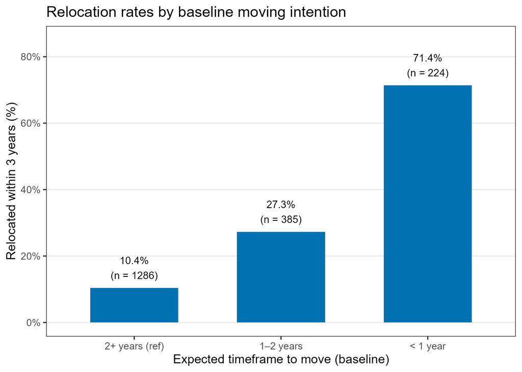

Relocation rates by baseline moving intention

**Model equations** (reference: no stated intention; Man):

$$\begin{aligned}
\text{M1:} \quad \text{logit}(p_i) &= \beta_0 + \beta_1\,\text{Int}_{2+\text{yr, intends}} + \beta_2\,\text{Int}_{1\text{–}2\,\text{yr}} + \beta_3\,\text{Int}_{<1\,\text{yr}} \\[6pt]
\text{M2:} \quad \text{logit}(p_i) &= \beta_0 + \beta_1\,\text{Int}_{2+\text{yr, intends}} + \beta_2\,\text{Int}_{1\text{–}2\,\text{yr}} + \beta_3\,\text{Int}_{<1\,\text{yr}} + \beta_4\,\text{Age} + \beta_5\,\text{Sex} + \beta_6\,\text{SRH}
\end{aligned}$$

Table 2: RQ1: Logistic regression — moving intentions predicting relocation

| **Characteristic** | **M1: Unadjusted** **OR** | **M1: Unadjusted** **95% CI** | **M1: Unadjusted** **p-value** | **M2: Adjusted** **OR** | **M2: Adjusted** **95% CI** | **M2: Adjusted** **p-value** |
| --- | --- | --- | --- | --- | --- | --- |
| Intention category |  |  |  |  |  |  |
| No stated intention (ref) | — | — |  | — | — |  |
| 2+ years, intends | 2.14 | 1.45, 3.12 | <0.001 | 2.08 | 1.41, 3.04 | <0.001 |
| 1–2 years | 4.05 | 2.94, 5.59 | <0.001 | 4.45 | 3.21, 6.19 | <0.001 |
| < 1 year | 26.3 | 18.3, 38.3 | <0.001 | 27.0 | 18.7, 39.6 | <0.001 |
| Age (per year) |  |  |  | 0.97 | 0.96, 0.99 | 0.004 |
| Sex |  |  |  |  |  |  |
| Man |  |  |  | — | — |  |
| Woman |  |  |  | 1.18 | 0.91, 1.54 | 0.2 |
| Self-rated health (1–5) |  |  |  | 1.11 | 0.97, 1.27 | 0.14 |

Abbreviations: CI = Confidence Interval, OR = Odds Ratio

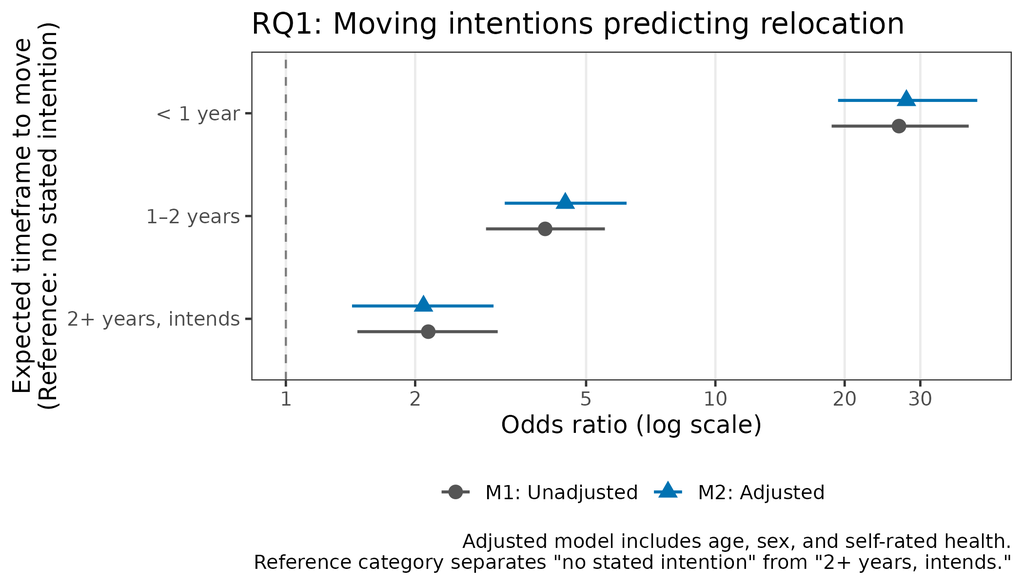

Forest plot: unadjusted vs adjusted ORs for moving intentions predicting relocation (RQ1)

#### Sequential decomposition: any intention vs. urgency

A single comparison against “no intention” across all four categories can read as tautological once the urgency gradient, which correlates with time-to-event by construction, is folded in. Splitting RQ1 into two sequential questions avoids this: Step A asks whether *any* stated intention (vs. none) predicts relocation; Step B asks, among those with a stated intention, whether urgency further predicts relocation.

Table 3: RQ1 sequential decomposition: any intention (Step A) vs. urgency among intenders (Step B)

| **Characteristic** | **Step A: Any intention** **OR** | **Step A: Any intention** **95% CI** | **Step A: Any intention** **p-value** | **Step B: Urgency among intenders** **OR** | **Step B: Urgency among intenders** **95% CI** | **Step B: Urgency among intenders** **p-value** |
| --- | --- | --- | --- | --- | --- | --- |
| Any intention (vs. none) |  |  |  |  |  |  |
| No | — | — |  |  |  |  |
| Yes | 5.85 | 4.49, 7.70 | <0.001 |  |  |  |
| Age (per year) | 0.98 | 0.96, 0.99 | 0.005 | 0.97 | 0.95, 0.99 | 0.003 |
| Sex |  |  |  |  |  |  |
| Man | — | — |  | — | — |  |
| Woman | 1.17 | 0.92, 1.50 | 0.2 | 1.29 | 0.94, 1.79 | 0.12 |
| Self-rated health (1–5) | 1.10 | 0.97, 1.25 | 0.13 | 1.09 | 0.93, 1.28 | 0.3 |
| Urgency (ref: 2+ years, intends) |  |  |  |  |  |  |
| 2+ years, intends (ref) |  |  |  | — | — |  |
| 1–2 years |  |  |  | 2.20 | 1.49, 3.28 | <0.001 |
| < 1 year |  |  |  | 13.3 | 8.68, 20.6 | <0.001 |

Abbreviations: CI = Confidence Interval, OR = Odds Ratio

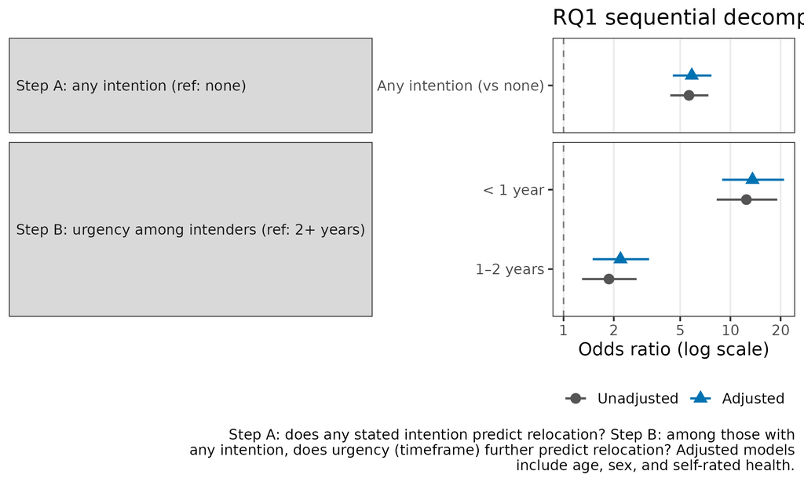

Sequential decomposition forest plot: any intention (Step A) vs. urgency among intenders (Step B)

#### Robustness: does the intention effect survive adjustment for socioeconomic status?

Table 4: RQ1 robustness: intention odds ratios before and after adjusting for register-measured SES

| **Characteristic** | **Survey-only** **OR** | **Survey-only** **95% CI** | **Survey-only** **p-value** | **+ Register SES** **OR** | **+ Register SES** **95% CI** | **+ Register SES** **p-value** |
| --- | --- | --- | --- | --- | --- | --- |
| Intention category |  |  |  |  |  |  |
| No stated intention (ref) | — | — |  | — | — |  |
| 2+ years, intends | 2.08 | 1.41, 3.05 | <0.001 | 1.99 | 1.35, 2.93 | <0.001 |
| 1–2 years | 4.45 | 3.21, 6.20 | <0.001 | 4.30 | 3.09, 6.00 | <0.001 |
| < 1 year | 27.4 | 18.9, 40.2 | <0.001 | 26.0 | 17.9, 38.4 | <0.001 |
| Age (per year) | 0.97 | 0.96, 0.99 | 0.004 | 0.96 | 0.94, 0.99 | 0.003 |
| Sex |  |  |  |  |  |  |
| Man | — | — |  | — | — |  |
| Woman | 1.18 | 0.91, 1.54 | 0.2 | 1.14 | 0.87, 1.50 | 0.3 |
| Self-rated health (1–5) | 1.10 | 0.96, 1.26 | 0.2 | 1.09 | 0.95, 1.25 | 0.2 |
| Disposable income (SEK/month) |  |  |  | 1.00 | 1.00, 1.00 | 0.082 |
| Marital status |  |  |  |  |  |  |
| Married |  |  |  | — | — |  |
| Cohabiting |  |  |  | 1.42 | 1.03, 1.96 | 0.031 |
| Single |  |  |  | 0.83 | 0.53, 1.28 | 0.4 |
| Widowed |  |  |  | 1.53 | 0.94, 2.45 | 0.082 |
| Other |  |  |  | 0.33 | 0.01, 4.10 | 0.4 |
| Employment status |  |  |  |  |  |  |
| Employed |  |  |  | — | — |  |
| Retired |  |  |  | 1.18 | 0.80, 1.72 | 0.4 |
| Other |  |  |  | 1.41 | 0.92, 2.15 | 0.11 |

Abbreviations: CI = Confidence Interval, OR = Odds Ratio

The intention odds ratios were essentially unchanged after adding register-measured income, marital status, and employment status (common n = 1829), arguing against a purely socioeconomic explanation for the intention-relocation association.

### RQ2: Housing factors add minimally beyond intentions

Home satisfaction was the only housing factor with an independent association with relocation (OR ≈ 0.76–0.86; lower satisfaction associated with higher odds of relocation). Housing suitability and neighborhood cohesion did not independently predict relocation on their own, though suitability becomes a significant *positive* predictor once satisfaction is added to the model (a suppression pattern; see below). Housing factors as a group added only marginally to the model beyond intentions (ΔNagelkerke R² = 0.008).

**Model equations** (M2 carried forward from RQ1; M6 adds housing factors):

$$\begin{aligned}
\text{M6:} \quad \text{logit}(p_i) &= \beta_0 + \boldsymbol{\beta}_{\text{int}} + \beta_4\,\text{Age} + \beta_5\,\text{Sex} + \beta_6\,\text{SRH} \\
&\quad + \beta_7\,\text{Suitability} + \beta_8\,\text{Satisfaction} + \beta_9\,\text{Cohesion}
\end{aligned}$$

Table 5: RQ2: Logistic regression — housing factors predicting relocation

| **Characteristic** | **M2: Intentions + demographics** **OR** | **M2: Intentions + demographics** **95% CI** | **M2: Intentions + demographics** **p-value** | **M6: + Housing factors** **OR** | **M6: + Housing factors** **95% CI** | **M6: + Housing factors** **p-value** |
| --- | --- | --- | --- | --- | --- | --- |
| Intention category |  |  |  |  |  |  |
| No stated intention (ref) | — | — |  | — | — |  |
| 2+ years, intends | 2.08 | 1.41, 3.04 | <0.001 | 2.05 | 1.38, 3.00 | <0.001 |
| 1–2 years | 4.45 | 3.21, 6.19 | <0.001 | 4.18 | 2.98, 5.88 | <0.001 |
| < 1 year | 27.0 | 18.7, 39.6 | <0.001 | 24.9 | 16.9, 36.9 | <0.001 |
| Age (per year) | 0.97 | 0.96, 0.99 | 0.004 | 0.97 | 0.96, 0.99 | 0.005 |
| Sex |  |  |  |  |  |  |
| Man | — | — |  | — | — |  |
| Woman | 1.18 | 0.91, 1.54 | 0.2 | 1.14 | 0.87, 1.49 | 0.4 |
| Self-rated health (1–5) | 1.11 | 0.97, 1.27 | 0.14 | 1.11 | 0.97, 1.28 | 0.13 |
| Housing suitability (1–5) |  |  |  | 1.44 | 1.09, 1.92 | 0.011 |
| Home satisfaction (1–5) |  |  |  | 0.76 | 0.64, 0.91 | 0.003 |
| Neighborhood cohesion (1–3) |  |  |  | 0.98 | 0.75, 1.29 | >0.9 |

Abbreviations: CI = Confidence Interval, OR = Odds Ratio

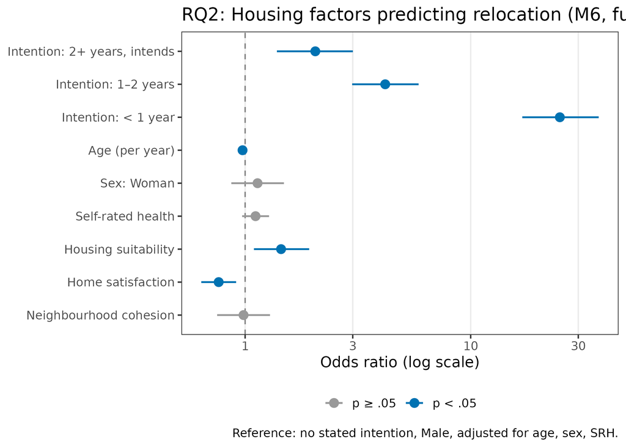

#### Is the housing suitability sign change collinearity or genuine suppression?

Rather than assume the sign change is a suppression effect, VIFs and bivariate correlations were computed directly. VIFs for the three housing-block variables in M6 were low (housing suitability = 1.35, home satisfaction = 1.51, neighbourhood cohesion = 1.1; all model terms < 1.6), well below conventional concern thresholds (5–10). Housing suitability and home satisfaction were moderately correlated (*r* = 0.5), while neighbourhood cohesion was weakly correlated with both. This rules out problematic multicollinearity: the sign change reflects genuine suppression between two correlated but non-redundant predictors.

A linearity-in-the-logit check (linear term vs. a fully saturated categorical version, compared by likelihood ratio test) did not reject the linear-term assumption for self-rated health, housing suitability, or home satisfaction (all *p* > .28), supporting their treatment as linear predictors throughout Paper 1:

Table 6: Linearity-in-the-logit check: linear term vs. fully saturated categorical term (LRT), M6 full model

| Variable | Δdf | p |
| --- | --- | --- |
| Self-rated health | 3 | 0.284 |
| Housing suitability | 14 | 0.480 |
| Home satisfaction | 3 | 0.384 |

### RQ3: Among intenders, who did not relocate?

Of the 609 participants who intended to move within two years, 344 (56%) had not relocated by T3. Within this subgroup:

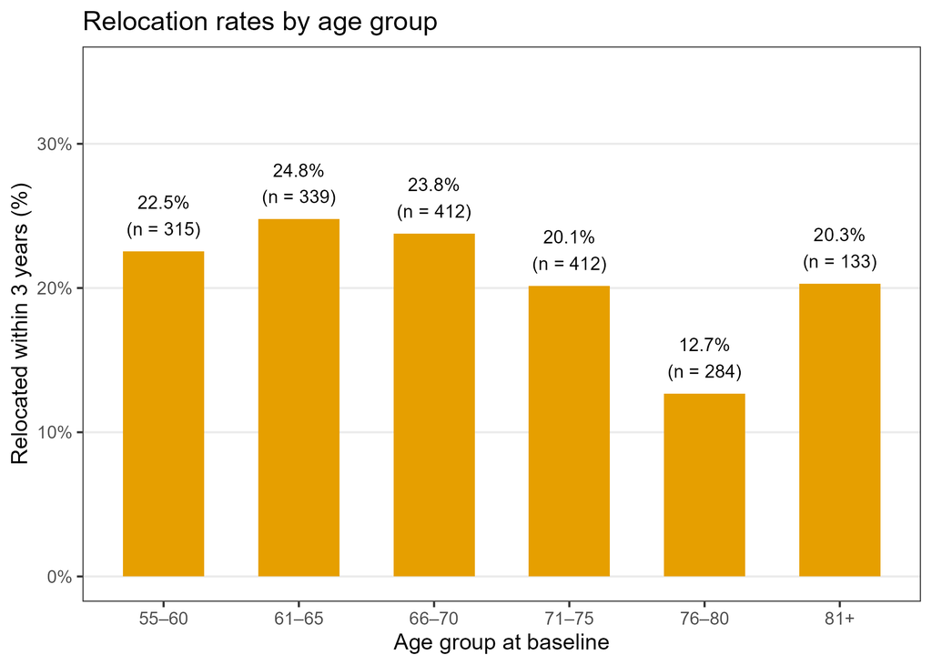

Relocation rates by age group

**Model equations** (intender subset; reference: intention 1–2 years, Man):

$$\begin{aligned}
\text{M1:} \quad \text{logit}(p_i) &= \beta_0 + \beta_1\,\text{Int}_{<1\,\text{yr}} + \beta_2\,\text{Age} + \beta_3\,\text{Sex} + \beta_4\,\text{SRH} \\[6pt]
\text{M4:} \quad \text{logit}(p_i) &= \beta_0 + \beta_1\,\text{Int}_{<1\,\text{yr}} + \beta_2\,\text{Age} + \beta_3\,\text{Sex} + \beta_4\,\text{SRH} \\
&\quad + \beta_5\,\text{Suitability} + \beta_6\,\text{Satisfaction} + \beta_7\,\text{Cohesion} \\
&\quad + \beta_8\,\text{AnyObstacle} + \sum_{k=9}^{15}\beta_k\,\text{Obstacle}_k
\end{aligned}$$

Table 7: RQ3: Logistic regression — predictors of relocation among intenders

| **Characteristic** | **M1: Baseline** **OR** | **M1: Baseline** **95% CI** | **M1: Baseline** **p-value** | **M4: Full model** **OR** | **M4: Full model** **95% CI** | **M4: Full model** **p-value** |
| --- | --- | --- | --- | --- | --- | --- |
| Intention (< 1 yr vs 1–2 yrs) |  |  |  |  |  |  |
| 1–2 years (ref) | — | — |  | — | — |  |
| < 1 year | 5.77 | 3.97, 8.46 | <0.001 | 5.69 | 3.87, 8.46 | <0.001 |
| Age (per year) | 0.96 | 0.94, 0.99 | 0.003 | 0.96 | 0.93, 0.98 | 0.001 |
| Sex |  |  |  |  |  |  |
| Man | — | — |  | — | — |  |
| Woman | 1.26 | 0.87, 1.84 | 0.2 | 1.35 | 0.91, 2.00 | 0.14 |
| Self-rated health (1–5) | 1.14 | 0.94, 1.38 | 0.2 | 1.10 | 0.89, 1.36 | 0.4 |
| Housing suitability (1–5) |  |  |  | 1.17 | 0.82, 1.66 | 0.4 |
| Home satisfaction (1–5) |  |  |  | 0.92 | 0.73, 1.16 | 0.5 |
| Neighborhood cohesion (1–3) |  |  |  | 1.18 | 0.79, 1.76 | 0.4 |
| Any obstacle |  |  |  | 0.65 | 0.31, 1.33 | 0.2 |
| Obstacle: Financial |  |  |  | 1.11 | 0.54, 2.31 | 0.8 |
| Obstacle: Limited supply |  |  |  | 0.90 | 0.43, 1.92 | 0.8 |
| Obstacle: No energy to move |  |  |  | 0.63 | 0.21, 1.73 | 0.4 |
| Obstacle: Own health |  |  |  | 2.04 | 0.60, 6.73 | 0.2 |
| Obstacle: Partner health |  |  |  | 1.59 | 0.45, 5.44 | 0.5 |
| Obstacle: Dependents |  |  |  | 0.17 | 0.02, 0.71 | 0.032 |
| Obstacle: Bulky goods |  |  |  | 0.41 | 0.07, 1.61 | 0.2 |

Abbreviations: CI = Confidence Interval, OR = Odds Ratio

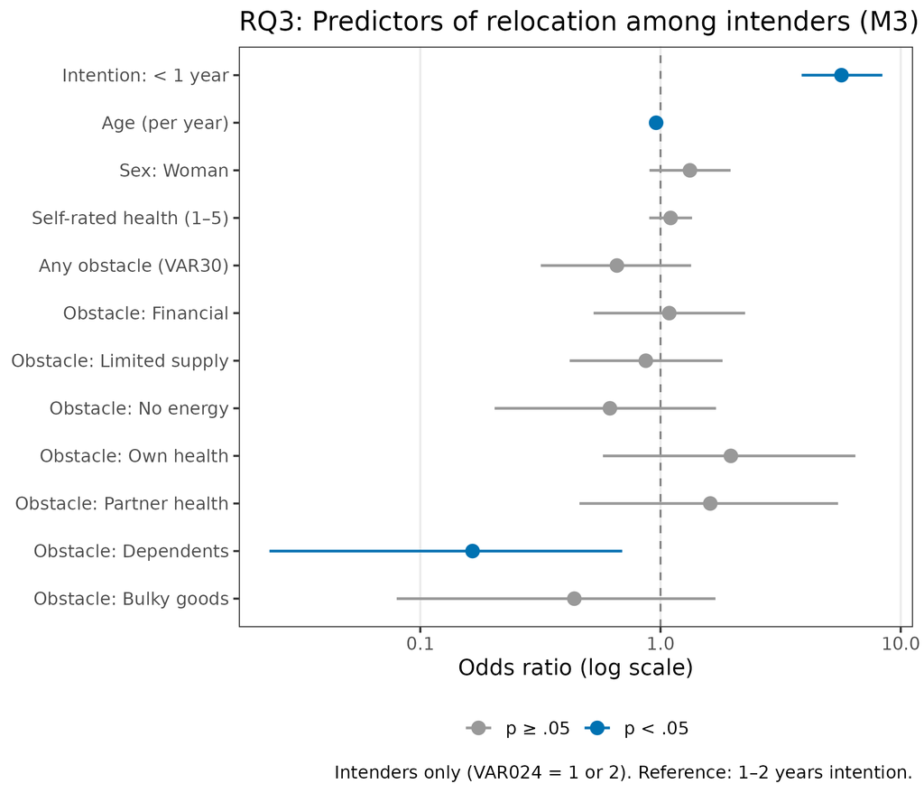

Forest plot: models among intenders (RQ3)

#### Small-cell sensitivity: the dependents finding, and model power

Only 18 respondents endorsed the dependents obstacle, so the standard maximum-likelihood estimate rests on a small cell. A Firth penalized logistic regression, more robust to rare-outcome/small-cell instability, gives OR = 0.21 (95% CI: 0.04–0.81), somewhat less extreme than the standard estimate (OR = 0.17) but confirming its direction and significance. This is specific to the dependents term, not a sign the RQ3 models are generally underpowered: events-per-variable for the full model (M4) was 17.2 (258 events / 15 predictors), above the conventional adequacy threshold of 10.

*Predictors of unexpected relocation among non-intenders are examined in Paper 2, RQ4.*

## Limitations

An earlier internal version of this analysis reported baseline N = 1,964; the six-person difference from the current N = 1,958 reflects additional exclusions applied during data cleaning and register linkage and does not affect any reported association.

Four limitations warrant attention. First, 545 participants did not respond at T3 and are administratively censored in survival analyses; the A8 attrition comparison shows non-response is associated with worse self-rated health and lower income (though not age), so this is not completely random. An IPCW-weighted sensitivity analysis (below) shows the survival conclusions are robust to this. Second, the sample is drawn from housing-company interest lists rather than the general older adult population; findings may not generalize to those who have not signaled relocation interest. Third, no time-varying measures of housing market conditions or individual financial capacity were available in the survey data; the Swedish rate-hike context (discussed in Paper 2) is therefore contextual rather than directly modelled. Register-linked income and employment variables are incorporated in supplementary models; see Register-based analyses. Fourth, RQ1 and the housing-factor tests in RQ2 were pre-specified and are treated as confirmatory; the obstacle-by-obstacle comparisons in RQ3 and the robustness checks (SES adjustment, VIF/linearity, Firth, IPCW) are exploratory and hypothesis-generating, and no correction for multiple comparisons was applied across this larger set of tests.

## Further analysis: Survival analysis

To complement the logistic regression results, Cox proportional hazards models were fitted using exact relocation dates. These dates are taken from the Swedish tax register, which records registered address changes precisely and therefore reflect actual move timing rather than survey recall. This approach additionally accounts for the varying length of follow-up across participants, as T1 surveys were completed between March and December 2021.

**Censoring rules:** Participants who relocated were assigned their exact tax-register move date. Non-relocators who responded at T3 were censored at their T3 survey date. Non-relocators who did not respond at T3 (n = 545) were administratively censored at 2024-11-13.

### Cumulative incidence by intention group

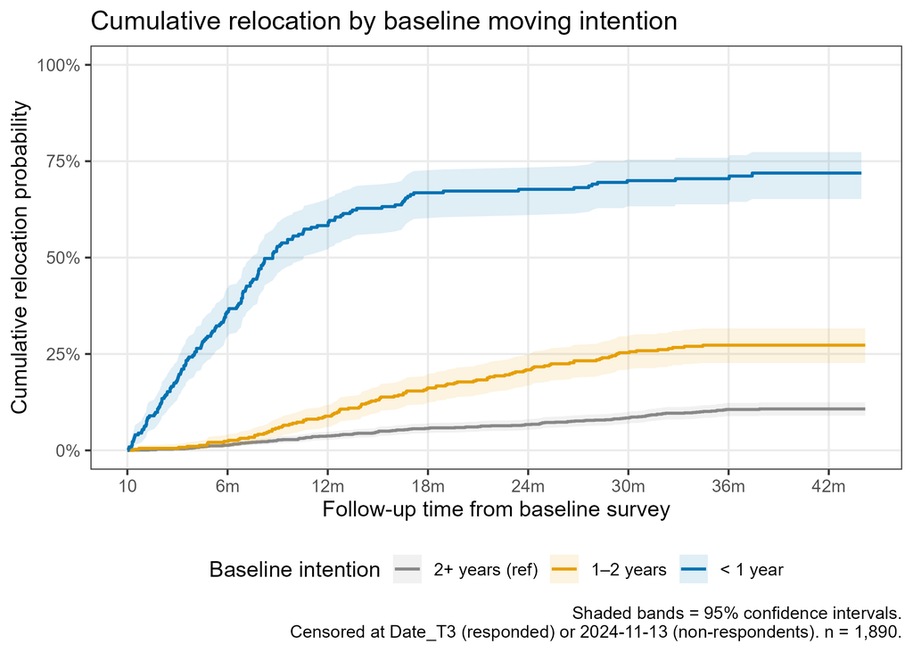

Cumulative relocation probability by baseline intention (Kaplan-Meier)

### Cox proportional hazards models

Table 8: Cox proportional hazards models for time to relocation

| **Characteristic** | **Cox M1: Unadjusted** **HR** | **Cox M1: Unadjusted** **95% CI** | **Cox M1: Unadjusted** **p-value** | **Cox M2: Adjusted** **HR** | **Cox M2: Adjusted** **95% CI** | **Cox M2: Adjusted** **p-value** |
| --- | --- | --- | --- | --- | --- | --- |
| Intention category |  |  |  |  |  |  |
| No stated intention (ref) | — | — |  | — | — |  |
| 2+ years, intends | 2.03 | 1.43, 2.88 | <0.001 | 1.99 | 1.40, 2.82 | <0.001 |
| 1–2 years | 3.49 | 2.61, 4.65 | <0.001 | 3.79 | 2.83, 5.07 | <0.001 |
| < 1 year | 17.1 | 13.1, 22.3 | <0.001 | 17.4 | 13.3, 22.8 | <0.001 |
| Age (per year) |  |  |  | 0.98 | 0.97, 0.99 | 0.004 |
| Sex |  |  |  |  |  |  |
| Man |  |  |  | — | — |  |
| Woman |  |  |  | 1.10 | 0.90, 1.35 | 0.4 |
| Self-rated health (1–5) |  |  |  | 1.10 | 1.00, 1.22 | 0.050 |

Abbreviations: CI = Confidence Interval, HR = Hazard Ratio

### Proportional hazards assumption

Table 9: Schoenfeld residuals test of proportional hazards (Cox M2)

| Term | χ² | df | p |
| --- | --- | --- | --- |
| Intention category | 56.805 | 3 | 0.0000 |
| Age | 0.002 | 1 | 0.9645 |
| Sex | 1.401 | 1 | 0.2366 |
| Self-rated health | 0.003 | 1 | 0.9547 |
| Global test | 59.424 | 6 | 0.0000 |

The proportional hazards assumption is **violated for the intention variable** (p < 0.001), consistent with the KM curves: the hazard of relocation in the `< 1 year` group is very high early in follow-up but attenuates over time as early movers are exhausted. All other predictors satisfy the assumption.

[figure not shown]

Schoenfeld residuals for intention category (Cox M2)

### Stratified Cox model

To obtain valid covariate estimates unaffected by the proportional hazards violation, a stratified Cox model was fitted with the four-level intention variable as the stratifying variable. This removes the hazard ratio for intention (conveyed by the KM curves instead) but ensures unbiased estimates for age, sex, health, and housing factors.

Table 10: Stratified Cox model (stratified by intention category)

Stratified Cox model: HRs for covariates, stratified by intention category. Reference: Man. n = 1,828.

| **Characteristic** | **HR** | **95% CI** | **p-value** |
| --- | --- | --- | --- |
| Age (per year) | 0.98 | 0.97, 0.99 | 0.005 |
| Sex |  |  |  |
| Man | — | — |  |
| Woman | 1.11 | 0.91, 1.37 | 0.3 |
| Self-rated health (1–5) | 1.09 | 0.99, 1.21 | 0.091 |
| Housing suitability (1–5) | 1.28 | 1.05, 1.55 | 0.014 |
| Home satisfaction (1–5) | 0.85 | 0.75, 0.95 | 0.006 |
| Neighborhood cohesion (1–3) | 1.04 | 0.84, 1.29 | 0.7 |

Abbreviations: CI = Confidence Interval, HR = Hazard Ratio

Results are consistent with logistic regression: lower home satisfaction is associated with higher hazard of relocation (HR = 0.85, p = 0.006). Housing suitability shows a positive association in the same direction as the suppression effect noted in RQ2. Neighborhood cohesion, sex, and self-rated health were not independently associated with time to relocation.

**Fix note:** a previous version of this stratified model called `survival::strata()` with the namespace prefix. `coxph()`’s formula parser matches special terms (`strata`, `cluster`, etc.) by literal text and does not recognise a namespace-qualified call, so it was silently fitting intention as ordinary covariates rather than truly stratifying by it. This has been corrected (bare `strata()`, with `survival` attached via `library()`), and the numbers above reflect the fix.

### Sensitivity: informative T3 non-response (IPCW)

T3 non-respondents are administratively censored at study end, but the A8 attrition comparison shows non-response is associated with income and health. To test whether this informative censoring distorts the stratified estimates, the model was refit with inverse-probability-of-censoring weights (age, sex, SRH, register income, marital status, employment status), restricted to respondents with a genuinely known end time (relocated, or T3-censored; *n* = 1301; administratively censored cases dropped, since their true end time is unknown).

Table 11: Sensitivity: IPCW-weighted stratified Cox model

IPCW-weighted stratified Cox model. Reference: Man. n = 1301.

| **Characteristic** | **HR** | **95% CI** | **p-value** |
| --- | --- | --- | --- |
| Age (per year) | 0.98 | 0.97, 0.99 | 0.003 |
| Sex |  |  |  |
| Man | — | — |  |
| Woman | 1.14 | 0.93, 1.40 | 0.2 |
| Self-rated health (1–5) | 1.04 | 0.93, 1.17 | 0.5 |
| Housing suitability (1–5) | 1.24 | 1.03, 1.50 | 0.024 |
| Home satisfaction (1–5) | 0.82 | 0.73, 0.92 | <0.001 |
| Neighborhood cohesion (1–3) | 1.14 | 0.91, 1.43 | 0.3 |

Abbreviations: CI = Confidence Interval, HR = Hazard Ratio

The housing-factor hazard ratios were essentially unchanged after IPCW adjustment (housing suitability: HR = 1.28 unweighted vs. 1.24 weighted; home satisfaction: HR = 0.85 vs. 0.82; both remained significant), indicating informative T3 non-response does not meaningfully bias the primary survival conclusions.

# Paper 2: Mismatch between plans and outcomes

**Paper 2 scope:** Subgroup analyses examining (a) why many intenders did not relocate (blocked movers, RQ3) and (b) what predicts relocation among those with no stated intent (unexpected movers, RQ4). The Swedish macro-economic context is used to interpret structural constraints on relocation.

## Abstract

**Background:** While moving intentions are the strongest predictor of residential relocation in later life, many intenders do not follow through and some non-intenders relocate unexpectedly. The factors driving these deviations from intention — particularly structural and environmental conditions — are poorly understood.

**Objective:** To identify factors associated with non-relocation among older adults who intended to move, and to examine what predicts unexpected relocation among those who did not intend to move.

**Methods:** Subgroup logistic regression analyses within a prospective longitudinal cohort (N = 1,958; Sweden 2021–2024). The blocked-intender subsample (n = 609) and the unexpected-mover subsample (n = 1,286 non-intenders, of whom 134 relocated) were analysed separately. A person-centered latent profile analysis (full results in appendix) identified the environmentally pressured profile as a theoretically salient subgroup.

**Conclusions:** Housing dissatisfaction and renter status are the primary drivers of reactive, unplanned relocation among older adults. The Swedish rate-hike cycle (2022–2023) likely locked many intending owners in place through market-level constraints that individual surveys cannot capture. These findings point to structural housing policy — particularly renter protections and accessible owner housing supply — as levers for improving residential outcomes among older adults.

## Background

The intention–behavior gap in residential mobility is well-documented: a substantial proportion of older adults who express a wish to relocate do not do so, while others relocate without prior stated intent. Paper 1 established that moving intentions are the dominant predictor of relocation in this cohort. The present paper addresses the two forms of mismatch that remain after accounting for intentions: *blocked movers* (intenders who did not relocate) and *unexpected movers* (non-intenders who did).

The theoretical frame for both groups comes from Lawton’s ecological model of aging [-@lawton1973ecology], which holds that residential behavior reflects the interplay between a person’s competence (health, functional capacity) and the press of their housing environment (physical fit, social context, tenure security). When environmental press is sufficiently strong — through housing dissatisfaction, neighborhood deterioration, or involuntary displacement via lease termination or rent increases — relocation can occur even without prior intent. Conversely, when structural barriers block an intended move despite adequate personal competence, the intention–behavior link breaks down.

The study period (2021–2024) provides a strong structural test of this model: Sweden experienced one of the sharpest housing market corrections in Europe, with the Riksbank raising its benchmark rate from 0% to 4% in approximately 18 months. This created asymmetric constraints — potentially locking owner-occupiers into their current dwellings while accelerating involuntary moves among renters through rising rents and lease pressure.

## Study aim and research questions

The aim of Paper 2 is twofold:

**(a)** To identify factors associated with non-relocation among older adults who intended to move at baseline.

**(b)** To identify factors predicting unexpected relocation among older adults who did not intend to move at baseline.

**Research questions:**

3. Among those who intended to move at baseline, which factors are associated with *not* having relocated after three years?
4. Among those who did not intend to move at baseline, which factors predict unexpected relocation?

## Macro-economic context: The Swedish housing market 2021–2024

The study period coincided with two shocks directly relevant to relocation behavior among older homeowners.

**Swedish interest rate trajectory (Riksbank)**

| Date | Riksbank rate |
| --- | --- |
| April 2022 | 0.25% |
| September 2022 | 1.75% |
| February 2023 | 3.00% |
| May 2023 | 3.50% |
| September 2023 | 4.00% (peak) |
| November 2024 | 2.75% (declining) |

Sweden’s benchmark rate rose from 0% to 4% in approximately 18 months, directly affecting housing transaction volumes and affordability.

**Housing price collapse**

Swedish residential property prices fell approximately 20% from peak (Q1 2022) to trough (Q4 2022 – Q1 2023) — one of the sharpest corrections in Europe during that period. The practical consequence for older homeowners intending to move: selling during 2022–2023 meant crystallizing a significant capital loss, effectively locking many intenders in place regardless of their stated intentions.

**Relocation timing by tenure**

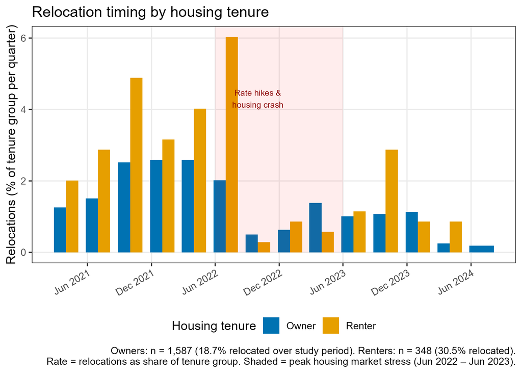

Relocation rates by quarter and housing tenure

Owner relocations show sustained suppression from mid-2022, consistent with sellers waiting out the downturn. Renters show an apparent spike in Q3 2022 — consistent with inflation-driven displacement — followed by sharp decline. The renter group is substantially smaller (n = 348) than the owner group (n = 1,587); quarterly figures represent small absolute numbers and are presented as descriptive context rather than formal tests.

These patterns cannot be formally tested within the current study design, which has no time-varying measures of housing market perceptions or individual financial capacity. They contextualise the intention-action gap: a proportion of the non-relocating intenders were likely constrained by structural market conditions rather than the personal barriers measured at baseline.

## Results

### RQ3: Blocked intenders — who did not relocate?

Of the 609 participants who intended to move within two years, 344 (56%) had not relocated by T3. Individual-level predictors — housing factors, perceived obstacles — were largely not predictive, consistent with the argument that the primary constraints during 2022–2023 were structural and market-level rather than personal.

The null finding for housing factors is theoretically informative: if the reason intenders did not move was that their housing was actually adequate, satisfaction and suitability should predict non-relocation. They do not. This points toward aggregate market conditions — falling prices, low transaction volumes, uncertain recovery — as the more plausible explanation, particularly for the large owner-occupier majority.

### RQ4: Unexpected movers — who relocated without intending to?

Of the 1,286 participants who did not expect to move within two years at baseline, 134 (10.4%) had relocated by T3. Predictors in this group differed markedly from the full-sample analyses.

- **Home satisfaction** was the dominant predictor (OR = 0.50, 95% CI: 0.38–0.65, p < 0.001). This effect is substantially stronger than in the full-sample model (OR ≈ 0.76–0.86 in RQ2), indicating that housing dissatisfaction is a particularly potent trigger for reactive, unplanned moves — consistent with Lawton’s environmental press overriding stated preferences.
- **Housing tenure:** renters were nearly twice as likely to relocate unexpectedly as owners (OR = 1.91, 95% CI: 1.18–3.01, p = 0.007), consistent with involuntary displacement — lease termination, rent increases. This aligns with the Q3 2022 renter spike in the tenure timing figure above.
- **Housing suitability** showed a positive association (OR ≈ 1.95–2.13, p < 0.05), likely reflecting collinearity with home satisfaction rather than a causal effect.
- **Neighborhood cohesion** was not independently associated with unexpected relocation.

Housing factors as a block added meaningfully to the model beyond demographics (LRT p < 0.001; ΔNagelkerke R² = 0.043), while demographics alone explained negligible variance (Nagelkerke R² = 0.006).

**Model equations** (non-intender subset; reference: Owner):

$$\begin{aligned}
\text{M1:} \quad & \text{logit}(p_i) = \beta_0 + \beta_1\,\text{Age} + \beta_2\,\text{Sex} + \beta_3\,\text{SRH} \\[6pt]
\text{M3:} \quad & \text{logit}(p_i) = \beta_0 + \beta_1\,\text{Age} + \beta_2\,\text{Sex} + \beta_3\,\text{SRH} \\
&\quad + \beta_4\,\text{Suitability} + \beta_5\,\text{Satisfaction} + \beta_6\,\text{Cohesion} + \beta_7\,\text{Tenure}
\end{aligned}$$

Table 12: RQ4: Logistic regression — predictors of unexpected relocation among non-intenders

| **Characteristic** | **M1: Demographics** **OR** | **M1: Demographics** **95% CI** | **M1: Demographics** **p-value** | **M3: Full model** **OR** | **M3: Full model** **95% CI** | **M3: Full model** **p-value** |
| --- | --- | --- | --- | --- | --- | --- |
| Age (per year) | 0.98 | 0.96, 1.01 | 0.2 | 0.98 | 0.96, 1.01 | 0.2 |
| Sex |  |  |  |  |  |  |
| Man | — | — |  | — | — |  |
| Woman | 1.15 | 0.79, 1.68 | 0.5 | 1.00 | 0.68, 1.47 | >0.9 |
| Self-rated health (1–5) | 1.05 | 0.87, 1.28 | 0.6 | 1.09 | 0.90, 1.33 | 0.4 |
| Housing suitability (1–5) |  |  |  | 2.13 | 1.31, 3.69 | 0.004 |
| Home satisfaction (1–5) |  |  |  | 0.50 | 0.38, 0.65 | <0.001 |
| Neighborhood cohesion (1–3) |  |  |  | 0.83 | 0.57, 1.21 | 0.3 |
| Tenure |  |  |  |  |  |  |
| Owner |  |  |  | — | — |  |
| Renter |  |  |  | 1.91 | 1.18, 3.01 | 0.007 |

Abbreviations: CI = Confidence Interval, OR = Odds Ratio

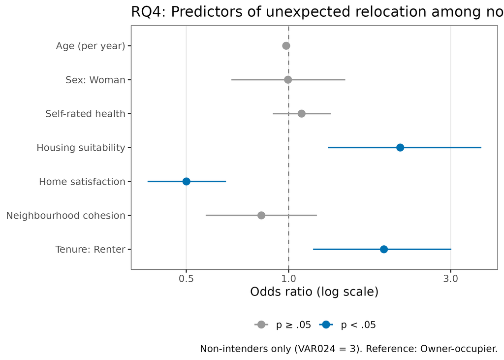

### Person-centered confirmation: latent profile analysis

A full latent profile analysis (LPA) is presented in the Appendix. Briefly, five profiles were identified from six baseline indicators (intention urgency, home satisfaction, housing suitability, self-rated health, age, neighborhood cohesion).

The theoretically most distinctive profile — **Profile 4: Environmentally pressured** (n = 134) — directly confirms the RQ4 findings from a person-centered perspective. This profile is defined by markedly low home satisfaction (mean 2.19/5, compared to ≥ 4.00 in all other profiles), the lowest neighborhood cohesion (1.87/3), moderate rather than urgent stated intention (mean 2.06), the highest proportion living alone (44.8%), and the lowest owner-occupancy rate (61.2%). Despite only moderate stated intention, **47% of this profile relocated**, producing odds of relocation of 6.95 (95% CI: 4.54–10.7) relative to the settled reference profile.

Table 13: LPA: Relocation odds by profile (reference: Profile 2, satisfied older stayers)

| Profile | OR<sup>1</sup> | 95% CI | p |
| --- | --- | --- | --- |
| 1 — Dissatisfied intenders | 2.79 | 1.99–3.93 | < 0.001 |
| 3 — Eager movers | 20.20 | 12.4–33.8 | < 0.001 |
| 4 — Environmentally pressured | 6.95 | 4.54–10.7 | < 0.001 |
| 5 — Satisfied younger stayers | 1.18 | 0.83–1.68 | 0.35 |

<sup>1</sup> Reference: Profile 2 — satisfied older stayers (n = 574; 11.3% relocated).

### Robustness: stratified Cox model

Results from the stratified Cox proportional hazards model (full methodology in Paper 1 survival analysis) are consistent with the logistic findings: housing dissatisfaction predicts shorter time to relocation (HR = 0.84, p = 0.005), confirming the RQ4 conclusions in a time-to-event framework.

## Limitations

Four limitations apply specifically to Paper 2. First, the distinction between voluntary and involuntary relocation cannot be directly observed — the renter interpretation rests on theoretical reasoning and contextual evidence rather than direct measurement. Second, the renter subgroup is small (n = 348); quarterly tenure-stratified figures in the macro-economic context section represent small absolute numbers and are descriptive rather than inferential. Third, housing market variables are aggregate and contextual — no individual-level measures of perceived financial capacity, housing market access, or lease security were available in the survey data. Fourth, register-derived income and objective housing characteristics were not yet available at time of analysis; planned register linkage will allow these to be added as predictors.

# Register-based analyses

The LISA register linkage extends the study’s analytic reach in two important ways. First, it allows us to assess the internal validity of the study — by checking whether survey attrition was random or selective, and by cross-validating survey-reported outcomes against administrative address records. Second, it enables the inclusion of socioeconomic and demographic variables that were not collected in the survey itself (income, marital status, employment status, regional location), allowing us to test whether the intention–behaviour gap and its predictors are robust to socioeconomic confounding.

## A8 — Attrition bias

A 33.8% loss to follow-up between T1 and T3 (n = 662 non-responders) raises the concern of **selective attrition**: if participants who dropped out differ systematically from those who completed T3, the associations estimated from the complete-case sample may not generalise to the broader population of interest. Selective attrition is especially consequential when the factors driving dropout are also related to the outcome (relocation). For example, if participants with lower income or poorer health were disproportionately lost to follow-up, and if these groups have lower relocation rates, the study might overestimate the overall prevalence of relocation or underestimate the role of structural barriers.

The table below compares T1 characteristics of T3 responders and non-responders across survey and register variables. Register variables (income, marital status, employment) are particularly valuable here because they were not available in earlier attrition checks based on survey data alone.

| **Variable** | **Non-responder** n = 662<sup>1</sup> | **T3 Responder** n = 1296<sup>1</sup> | **p**<sup>2</sup> |
| --- | --- | --- | --- |
| Age (years) | 68.66 (8.24) | 68.78 (7.39) | 0.762 |
| Sex |  |  | 0.773 |
| Man | 299 (45.2%) | 575 (44.4%) |  |
| Woman | 363 (54.8%) | 721 (55.6%) |  |
| Self-rated health (1–5) |  |  | 0.007 |
| 1 | 11 (1.7%) | 13 (1.0%) |  |
| 2 | 128 (19.4%) | 177 (13.7%) |  |
| 3 | 220 (33.3%) | 439 (34.0%) |  |
| 4 | 190 (28.8%) | 434 (33.6%) |  |
| 5 | 111 (16.8%) | 230 (17.8%) |  |
| Unknown | 2 | 3 |  |
| Moving intention category |  |  | 0.009 |
| No stated intention (ref) | 298 (46.9%) | 681 (54.1%) |  |
| 2+ years, intends | 123 (19.3%) | 184 (14.6%) |  |
| 1–2 years | 140 (22.0%) | 245 (19.5%) |  |
| < 1 year | 75 (11.8%) | 149 (11.8%) |  |
| Unknown | 26 | 37 |  |
| Housing suitability (1–5) | 4.68 (0.58) | 4.74 (0.51) | 0.017 |
| Unknown | 10 | 15 |  |
| Disposable household income (SEK/month) | 3,608.60 (2,808.96) | 3,926.00 (3,925.40) | 0.040 |
| Unknown | 7 | 0 |  |
| Marital status (register) |  |  | 0.568 |
| Married | 378 (57.7%) | 755 (58.3%) |  |
| Cohabiting | 147 (22.4%) | 274 (21.1%) |  |
| Single | 82 (12.5%) | 156 (12.0%) |  |
| Widowed | 48 (7.3%) | 107 (8.3%) |  |
| Other | 0 (0.0%) | 4 (0.3%) |  |
| Unknown | 7 | 0 |  |
| Employment status (register) |  |  | 0.227 |
| Employed | 276 (42.1%) | 507 (39.1%) |  |
| Retired | 285 (43.5%) | 568 (43.8%) |  |
| Other | 94 (14.4%) | 221 (17.1%) |  |
| Unknown | 7 | 0 |  |

<sup>1</sup> Mean (SD); n (%)  
<sup>2</sup> Welch Two Sample t-test; Pearson’s Chi-squared test

**Interpreting the attrition table.** Differences on baseline characteristics between responders and non-responders indicate that attrition is not entirely at random. Age and health differences are common in longitudinal studies of older adults, and a somewhat older or less healthy non-responder group would be expected and broadly in line with random informative dropout. More consequential for the study’s validity would be systematic differences on intention timeframe (if intenders selectively dropped out, the intention–behaviour gap estimate would be biased) or on income and marital status (if structurally vulnerable participants were lost, estimates of SES effects would be attenuated). Where statistically significant differences are observed, sensitivity analyses or inverse-probability weighting in subsequent work should be considered. Where differences are non-significant and effect sizes are small, the complete-case sample can be treated as broadly representative of the T1 cohort.

## A7 — Outcome validation

The study’s relocation outcome is based on self-report at T3: participants were asked whether they had moved to a new home since T1. This means that the 662 participants who did not complete T3 are treated as **censored** — their relocation status is unknown and they are coded as 0 (not relocated) in survival analyses or excluded entirely in cross-sectional models. However, some of these non-responders may have in fact relocated; they may have failed to return the T3 questionnaire precisely because they had recently moved and were no longer receiving mail at their previous address, or because the disruption of moving led them to deprioritise the survey. If this is the case, the study’s overall relocation rate (20.6%) would be systematically **underestimated**, and the association between intention and behaviour would be **conservative**.

The register provides a way to partially resolve this ambiguity. By comparing each T3 non-responder’s municipality and county of residence at T1 against their registered address at T3, we can identify probable moves that were never captured by the survey. Deaths and de-registrations (emigrations) explain another portion of non-response that is completely non-informative about the intention–behaviour relationship.

For T3 non-responders, we classify the likely reason for non-response using register data: death, de-registration (emigration), address change (probable relocation), or no change detected.

T3 non-responders: classification by register data

| Status | n | % |
| --- | --- | --- |
| No address change (likely no move) | 565 | 85.3 |
| De-registered (emigrated) | 41 | 6.2 |
| County change (probable move) | 28 | 4.2 |
| Municipality change (probable move) | 28 | 4.2 |

## A1–3 — Extended RQ models with register covariates

The core models in Papers 1 and 2 rely entirely on survey-measured predictors. A persistent concern in this literature is that socioeconomic factors — particularly income and wealth — both shape the desire to move and determine the ability to act on that desire. A low-income older adult may intend to move to a more suitable home but be unable to afford a move in the prevailing housing market. Conversely, a high-income retiree may have both the preference and the means to act quickly on a stated intention. If income is positively correlated with both intentions and realisation, survey-only models may confound these two mechanisms.

Three register variables address this concern directly:

- **Disposable household income (`disp_ink_ke`, SEK/month):** A standardised, equivalence-weighted measure of household income from LISA, capturing both labour income and transfers. This is a more objective and precise measure than the survey’s self-report of financial satisfaction. It captures the financial capacity to act on intentions.
- **Marital status (`civil_f`):** Goes beyond the binary survey `lives_alone` item to capture five legal categories. Widowhood is theoretically important as a trigger for reactive relocation — losing a partner often leaves an older adult in a home that is too large, too expensive, or too socially isolated. Cohabiting and married individuals have shared decision-making and potentially dual resources.
- **Employment/retirement status (`syss_f`):** Retirement is a major life-course transition that removes geographic constraints tied to employment. Retired individuals may have both the time and the freedom to relocate. In Swedish pension policy, retirement income is relatively stable, making employment status partly a proxy for life stage rather than purely economic position.

The extended model (m_reg, equivalent to `m2_ses` used in the Paper 1 RQ1 robustness check) adds all three register predictors to the m2 demographic baseline (intention category + age + sex + self-rated health). The AIC comparison assesses whether register variables improve model fit beyond what is achievable with survey data alone — if AIC is substantially lower, this suggests register-based SES confounding is real and that Papers 1–2 models should be interpreted with appropriate caution about residual confounding.

Income, marital status, and employment status are added as covariates to the primary logistic models.

Extended RQ1 model with register covariates (OR, 95% CI)

| **Characteristic** | **OR** | **95% CI** | **p-value** |
| --- | --- | --- | --- |
| Moving intention category |  |  |  |
| No stated intention (ref) | — | — |  |
| 2+ years, intends | 2.01 | 1.36, 2.93 | <0.001 |
| 1–2 years | 4.33 | 3.12, 6.04 | <0.001 |
| < 1 year | 27.0 | 18.6, 39.8 | <0.001 |
| Age (years) | 0.96 | 0.94, 0.99 | 0.002 |
| Sex |  |  |  |
| Man | — | — |  |
| Woman | 1.12 | 0.85, 1.46 | 0.4 |
| Self-rated health | 1.09 | 0.95, 1.25 | 0.2 |
| Disposable income (SEK/month) | 1.00 | 1.00, 1.00 | 0.068 |
| Marital status |  |  |  |
| Married | — | — |  |
| Cohabiting | 1.43 | 1.04, 1.95 | 0.029 |
| Single | 0.78 | 0.50, 1.19 | 0.3 |
| Widowed | 1.58 | 0.98, 2.51 | 0.057 |
| Other | 0.33 | 0.01, 4.06 | 0.4 |
| Employment status |  |  |  |
| Employed | — | — |  |
| Retired | 1.14 | 0.79, 1.67 | 0.5 |
| Other | 1.39 | 0.91, 2.10 | 0.12 |

Abbreviations: CI = Confidence Interval, OR = Odds Ratio

**Interpreting the extended model.** Attention should first go to whether the intention coefficients change materially after adding register covariates (comparing ORs in m_reg versus m2). They do not: e.g. the < 1 year OR is 27 in m2 (survey-only) and 27 in m_reg (with register SES) — only a small shift, strengthening the conclusion that intentions have independent predictive value beyond socioeconomic circumstances. Widowhood (relative to married) and single-person household status are of particular interest: positive, statistically significant coefficients would support a reactive relocation narrative in which structural circumstances, not preferences, drive moves.

AIC comparison with base model (m2, survey variables only):

AIC comparison: base vs. register-extended model

| Model | AIC | N |
| --- | --- | --- |
| m2 (survey) | 1,520.8 | 1828 |
| m_reg (survey + register) | 1,549.2 | 1885 |

**RQ4 extended — non-intenders with register covariates:**

The RQ4 analysis asks why some non-intenders (those who stated at T1 that they did not expect to move in the foreseeable future) nonetheless relocated by T3. This “unexpected relocation” group is central to Paper 2’s narrative about reactive, circumstance-driven moves. The survey-only model (m3_rq4) identified housing suitability and home satisfaction as predictors, consistent with an environmental press account. The register-extended model adds a crucial SES dimension: do non-intenders with lower income, without a partner (widowed or single), or who were recently retired relocate at higher rates, even holding housing conditions constant? If so, it suggests that structural vulnerability — not just perceived housing inadequacy — drives unexpected moves. This has direct policy implications: interventions aimed at preventing unwanted forced relocation among older adults should target structurally vulnerable individuals proactively, not wait for housing conditions to deteriorate.

RQ4 extended: non-intenders with register covariates (OR, 95% CI)

| **Characteristic** | **OR** | **95% CI** | **p-value** |
| --- | --- | --- | --- |
| Age (years) | 0.94 | 0.91, 0.98 | 0.003 |
| Sex |  |  |  |
| Man | — | — |  |
| Woman | 0.88 | 0.60, 1.31 | 0.5 |
| Self-rated health | 1.09 | 0.89, 1.33 | 0.4 |
| Housing suitability (1–5) | 2.01 | 1.23, 3.49 | 0.008 |
| Home satisfaction (1–5) | 0.49 | 0.38, 0.65 | <0.001 |
| Disposable income (SEK/month) | 1.00 | 1.00, 1.00 | 0.3 |
| Marital status |  |  |  |
| Married | — | — |  |
| Cohabiting | 2.03 | 1.29, 3.14 | 0.002 |
| Single | 0.69 | 0.33, 1.34 | 0.3 |
| Widowed | 2.56 | 1.25, 4.95 | 0.007 |
| Other | 0.00 |  | >0.9 |
| Employment status |  |  |  |
| Employed | — | — |  |
| Retired | 1.88 | 1.07, 3.32 | 0.027 |
| Other | 1.88 | 0.98, 3.53 | 0.055 |

Abbreviations: CI = Confidence Interval, OR = Odds Ratio

## A4 — Regional variation

The Swedish housing market is not uniform. The three metropolitan counties — Stockholm (county 01), Västra Götaland/Gothenburg (county 14), and Skåne/Malmö (county 12) — are characterised by high demand, constrained supply, long waiting lists for social housing, and elevated property prices. Non-metropolitan counties face different dynamics: less competition for housing but also fewer housing options tailored to older adults (e.g., service apartments, senior-specific developments). These structural differences have at least two countervailing implications for relocation among older adults:

1. **Higher barrier in metro areas:** Even if an older adult intends to move to a more suitable home, actually finding and securing appropriate housing is harder in metropolitan markets. Long queuing times for rental apartments and high prices for owner-occupied homes may delay or prevent intended moves, widening the intention–action gap.
2. **Greater variety in metro areas:** Metropolitan areas may also offer more diverse housing options (smaller apartments, step-free access, proximity to services), making it easier for those who do find suitable housing to act on intentions.

Whether relocation rates are higher or lower in metropolitan areas — and whether the association between intention and relocation differs by region — is therefore an empirical question. The metro/non-metro classification is a simplification (the `region` variable collapses 25 counties into two categories), but it provides a first-pass test of whether housing market context moderates the study’s main findings.

Relocation rates by metropolitan vs. non-metropolitan region, and the effect of region in the main RQ2 model.

Relocation rates by region

| Region | N | Relocated | % Relocated |
| --- | --- | --- | --- |
| Metro | 788 | 180 | 22.8 |
| Non-metro | 1163 | 224 | 19.3 |

**Interpreting the relocation rate table.** A higher relocation rate in one region does not by itself indicate a housing-market effect — it may simply reflect different distributions of intentions, age, or housing satisfaction across regions. The model below (m6 + region) adjusts for these survey-measured factors and estimates the residual regional effect.

Region as covariate in m6:

Region coefficient from m6 extended (OR, 95% CI)

| **Characteristic** | **OR** | **95% CI** | **p-value** |
| --- | --- | --- | --- |
| Region (Metro vs. Non-metro) |  |  |  |
| Metro | — | — |  |
| Non-metro | 0.81 | 0.62, 1.05 | 0.11 |

Abbreviations: CI = Confidence Interval, OR = Odds Ratio

**Interpreting the region coefficient.** A statistically significant positive OR for metro (relative to non-metro) would indicate higher odds of relocation in metropolitan areas after adjusting for intentions, demographics, and housing satisfaction — consistent with greater housing market activity (more transactions, easier to find a match). A non-significant or negative OR would support the barrier hypothesis (constrained supply offsets or reverses any advantage). A non-significant result should not be interpreted as evidence that regional context is unimportant — the crude metro/non-metro classification may not have sufficient resolution to detect the relevant variation. The lack of county-level or municipality-level fixed effects is an acknowledged limitation of this analysis.

## A5 — Capital income as moderator

Most relocation research focuses on income as a linear predictor of moving, but a theoretically important question is whether financial resources specifically **moderate the relationship between intentions and behaviour**. The Theory of Planned Behaviour predicts that behavioural intention is the proximal determinant of action, but that intention can only be realised when the individual has the perceived and actual capacity to act. Among older Swedish adults, who are overwhelmingly homeowners with long residential histories, **capital income** — income from investments, rental properties, and financial assets — is a particularly relevant indicator of financial capacity. Unlike labour income (which is largely absent among retirees), capital income reflects accumulated wealth that can be drawn upon to fund a move: covering transaction costs, bridging between selling an old home and buying a new one, or affording a deposit in a competitive rental market.

The interaction model tests whether higher capital income amplifies the effect of earlier intentions on relocation. If the interaction term is positive and statistically significant, it means that intenders with greater capital income are substantially more likely to realise their intentions than intenders with lower capital income — consistent with a financial-capacity model of the intention–action gap. A null interaction would suggest that financial resources are either sufficient for most participants (ceiling effect), irrelevant to the barriers that prevent intention realisation, or that labour income (captured elsewhere) is the more important financial determinant.

Test whether capital income moderates the intention–action gap.

Capital income as moderator (OR, 95% CI); interaction with intention timeframe

| **Characteristic** | **OR** | **95% CI** | **p-value** |
| --- | --- | --- | --- |
| Expected timeframe to move |  |  |  |
| 2+ years (ref) | — | — |  |
| 1–2 years | 3.17 | 2.33, 4.31 | <0.001 |
| < 1 year | 21.6 | 15.1, 31.2 | <0.001 |
| Capital income (SEK) | 1.00 | 1.00, 1.00 | 0.6 |
| Age (years) | 0.97 | 0.96, 0.99 | 0.002 |
| Sex |  |  |  |
| Man | — | — |  |
| Woman | 1.18 | 0.91, 1.54 | 0.2 |
| Self-rated health | 1.08 | 0.95, 1.24 | 0.2 |
| Expected timeframe to move * Capital income (SEK) |  |  |  |
| 1–2 years * Capital income (SEK) | 1.00 | 1.00, 1.00 | 0.004 |
| < 1 year * Capital income (SEK) | 1.00 | 1.00, 1.00 | 0.5 |

Abbreviations: CI = Confidence Interval, OR = Odds Ratio

## A6 — Household composition validation

Household composition — specifically, whether an individual lives alone or with a partner — is a theoretically important variable in this study. It appears as a predictor in RQ4 models and as an auxiliary variable in the LPA (Profile 4’s high proportion of single-person households being a key feature of its structural vulnerability interpretation). The survey measures this through a direct question (`VAR011_1`, household type), while the LISA register codes household type (`hushalls_typ_rtb`) based on registered addresses of all household members.

Cross-validating these two sources serves three purposes:

1. **Quality assurance:** A high agreement rate confirms that the survey item is reliable and that participants were not systematically misreporting their living arrangements.
2. **Construct validation:** The survey and register measures are not identical — couples who are not yet cohabiting, or who are registered at separate addresses for administrative reasons, may appear as “single” in the register but “not alone” in the survey. Understanding the direction and magnitude of discordance helps interpret which measure is more appropriate for each research question.
3. **LPA robustness:** Profile 4’s interpretation rests partly on its high proportion of single-person households. If this classification is unreliable (low kappa), the profile’s structural vulnerability narrative would need to be qualified.

Cross-validation of survey single-person household (`VAR011_1 == 1`) against register household type (`hushalls_typ_rtb`).

Cross-validation: register household type vs. survey single-person household

| Register household type | Survey: lives alone (0 = No, 1 = Yes) 0 | Survey: lives alone (0 = No, 1 = Yes) 1 |
| --- | --- | --- |
| Couple | 1102 | 11 |
| Other | 211 | 46 |
| Single | 63 | 505 |

```
Cohen's kappa (register vs. survey single-person household): 0.850
```

**Interpreting the cross-tabulation and kappa.** The cross-tabulation shows where the two measures agree (diagonal cells) and where they diverge (off-diagonal cells). The most informative off-diagonal cell is “Single (register) × Not alone (survey)” — individuals the register classifies as single-person households but who report living with someone. These cases likely reflect administrative lag (a partner who has moved in but not yet re-registered) or survey-register definitional differences. Cohen’s kappa provides a single summary of agreement corrected for chance: κ ≥ 0.80 indicates near-perfect agreement and validates the survey measure; κ = 0.60–0.79 indicates substantial agreement, acceptable for the purposes of the LPA auxiliary variable; κ < 0.60 would raise concerns and suggest that the two measures capture meaningfully different aspects of living arrangements, warranting a sensitivity analysis replacing the survey item with the register measure in key models.

# Project status

| Milestone | Status |
| --- | --- |
| Data collection (T1–T3) | ✅ Complete |
| Data cleaning & translation | ✅ Complete |
| RQ1 Analysis | ✅ Complete |
| RQ2 Analysis | ✅ Complete |
| RQ3 Analysis | ✅ Complete |
| RQ4 Analysis | ✅ Complete |
| Survival analysis | ✅ Complete |
| Latent profile analysis | ✅ Complete |
| Forest plots (RQ1–RQ4) | ✅ Complete |
| Paper 1 manuscript drafting | 🔄 In progress |
| Paper 2 manuscript drafting | 🔄 In progress |
| Register data linkage | ✅ Complete |
| Register-based analyses | ✅ Complete |
| Submission (Paper 1) | ⏳ Pending |
| Submission (Paper 2) | ⏳ Pending |

# Repository and reproducibility

All analysis code is available in the project repository. Scripts are numbered and run in order from the project root:

**Data pipeline (`scripts/01_clean/`)**

| Step | Script | Output |
| --- | --- | --- |
| 1 | `01_import.R` | `data/processed/survey_clean.rds` |
| 2 | `02_recode.R` | `data/processed/survey_analysis.rds` |
| 3 | `04_pivot_panel.R` | `data/processed/survey_panel.rds` |
| 4 | `05_merge_register.R` | `data/processed/panel_merged.rds` |

**Paper analyses**

| Folder | Scripts | Outputs |
| --- | --- | --- |
| `paper/descriptive/` | `00_cohort_tracking.R` | Attrition and Table 1 CSVs |
| `paper/paper1/analysis/` | `01_RQ1.R`, `02_RQ2.R`, `03_RQ3.R`, `04_survival.R` | Figures, tables, models |
| `paper/paper2/analysis/` | `01_RQ3_blocked.R`, `02_RQ4.R`, `03_LPA.R` | Figures, tables, models |

All paper scripts read `data/processed/panel_merged.rds` and filter to `wave == "T1"` for cross-sectional baseline analyses. Outputs are saved to `paper/paperX/figures/` (PNG, 300 dpi), `paper/paperX/tables/` (CSV), and `paper/paperX/models/` (RDS).

# Contact

For questions about this project, please reach out via the project repository.

## Appendix: Full latent profile analysis

## A.1 Rationale and theoretical background

The regression analyses in Papers 1 and 2 adopt a variable-centered perspective, asking which predictors are associated with relocation while averaging over individual differences. Latent Profile Analysis (LPA) complements this by taking a person-centered perspective: instead of asking “what variables predict the outcome?”, it asks “what types of people exist in this sample, and how do those types relate to relocation?”

## A.2 Analytic approach

**Indicators.** Six continuous baseline variables were included:

| Indicator | Original scale | Rationale |
| --- | --- | --- |
| Intention urgency | 1 (low) to 3 (urgent) | Expressed motivation to relocate |
| Home satisfaction | 1–5 | Affective appraisal of current home |
| Housing suitability | 1–5 | Physical fit between home and needs |
| Self-rated health | 1–5 | Personal competence (Lawton) |
| Age | Years | Developmental stage |
| Neighborhood cohesion | 1–3 | Social dimension of environmental press |

Binary variables (homeownership, living alone) were excluded from fitting and used as auxiliary descriptors after profile assignment. All indicators were z-standardized before fitting.

**Model fitting.** Models were fitted using `mclust` (EEI covariance structure; k = 2–6 profiles). A more flexible varying-variance model (VVI) did not converge for any number of profiles in this dataset, so EEI was the only evaluated model class. Model selection used BIC (mclust convention: higher = better) and entropy (> 0.70 acceptable). Minimum profile size: n > 50.

Table 14: LPA model fit: BIC and entropy for k = 2 to 6 profiles (EEI model)

| k | BIC<sup>1</sup> | Entropy<sup>2</sup> | Min n | Selected |
| --- | --- | --- | --- | --- |
| 2 | -29,391 | 0.984 | — |  |
| 3 | -28,550 | 0.952 | — |  |
| 4 | -28,548 | 0.715 | — |  |
| 5 | -26,431 | 0.785 | 104 | ✓ |
| 6 | -26,481 | 0.696 | — |  |

<sup>1</sup> BIC: higher (less negative) = better fit.  
<sup>2</sup> Entropy > 0.70 = adequate profile separation.

The five-profile solution achieved the highest BIC and adequate entropy (0.785). Analytic sample: N = 1,799 with complete data on all six indicators.

## A.3 Profile descriptions

Table 15: LPA profile characteristics: indicator means and auxiliary variables (original scales)

| Profile | n | LPA indicators (means) Intention (1–3)<sup>1</sup> | LPA indicators (means) Home satisfaction (1–5) | LPA indicators (means) Housing suitability (1–5) | LPA indicators (means) Self-rated health (1–5) | LPA indicators (means) Age (years) | LPA indicators (means) Neighborhood cohesion (1–3) | Auxiliary variables Living alone (%)<sup>2</sup> | Auxiliary variables Owner- occupied (%) | Auxiliary variables Relocated (%) |
| --- | --- | --- | --- | --- | --- | --- | --- | --- | --- | --- |
| 1 — Dissatisfied intenders | 400 | 1.66 | 4.00 | 4.47 | 3.30 | 68.3 | 2.02 | 34.2 | 73.5 | 26.2 |
| 2 — Satisfied older stayers | 574 | 1.22 | 5.00 | 4.86 | 3.05 | 74.4 | 2.31 | 23.0 | 87.3 | 11.3 |
| 3 — Eager movers | 104 | 3.00 | 5.00 | 4.91 | 3.62 | 68.9 | 2.14 | 26.9 | 85.6 | 72.1 |
| 4 — Environmentally pressured | 134 | 2.06 | 2.19 | 3.99 | 3.17 | 67.2 | 1.87 | 44.8 | 61.2 | 47.0 |
| 5 — Satisfied younger stayers | 587 | 1.10 | 5.00 | 4.89 | 4.09 | 63.2 | 2.22 | 25.4 | 87.1 | 13.1 |

<sup>1</sup> Intention urgency: 1 = not within 2 years, 2 = within 1–2 years, 3 = within 1 year. Profile 2 is the logistic regression reference.  
<sup>2</sup> Living alone and owner-occupied are auxiliary variables not used in LPA fitting.

**Profile 1 — Dissatisfied intenders (n = 400; 26% relocated).** Moderate moving intention (1.66) paired with below-average home satisfaction (4.00) and somewhat lower suitability (4.47). Over one in four relocated — more than double the settled profiles but well below the eager movers.

**Profile 2 — Satisfied older stayers (n = 574; 11% relocated) — reference.** Oldest participants (mean age 74.4), low intention, maximum satisfaction and suitability, highest neighborhood cohesion. Highest owner-occupancy (87.3%), lowest proportion living alone (23.0%). Lowest relocation rate (11.3%).

**Profile 4 — Environmentally pressured (n = 134; 47% relocated).** *Discussed in depth in Paper 2.* Markedly low satisfaction (2.19/5), lowest suitability (3.99) and neighborhood cohesion (1.87) in the sample. Moderate intention (2.06). Highest proportion living alone (44.8%), lowest owner-occupancy (61.2%). Nearly half relocated despite only moderate stated intent — driven by environmental press rather than planned preference.

**Profile 5 — Satisfied younger stayers (n = 587; 13% relocated).** Lowest intention (1.10), maximum satisfaction, highest self-rated health (4.09), youngest mean age (63.2). Low relocation comparable to Profile 2, but these are younger adults with strong housing fit who likely registered as a precautionary measure rather than in response to imminent need.

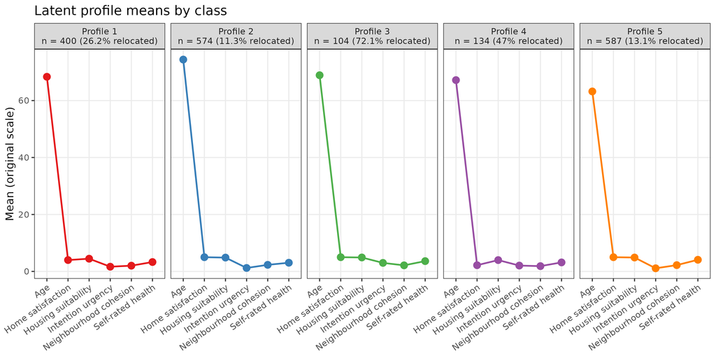

Latent profile analysis: mean indicator values by profile (original scales)

## A.4 Relocation odds by profile

Table 16: LPA: Logistic regression — profile membership predicting relocation (reference: Profile 2, satisfied older stayers)

| Profile | OR<sup>1</sup> | 95% CI | p |
| --- | --- | --- | --- |
| 1 — Dissatisfied intenders | 2.79 | 1.99–3.93 | < 0.001 |
| 3 — Eager movers | 20.20 | 12.4–33.8 | < 0.001 |
| 4 — Environmentally pressured | 6.95 | 4.54–10.7 | < 0.001 |
| 5 — Satisfied younger stayers | 1.18 | 0.83–1.68 | 0.35 |

<sup>1</sup> Reference: Profile 2 — satisfied older stayers (n = 574; 11.3% relocated). OR = odds ratio.

## A.5 Interpretation

**Intentions remain central but are not sufficient.** Profile 3 (OR = 20.2) confirms the dominant role of intentions. Crucially, these highly intentional individuals are also housing-satisfied — pointing to proactive, planned moves rather than reactive relocation.

**The two settled profiles behave similarly but for different reasons.** Profiles 2 and 5 are statistically indistinguishable in relocation odds but represent structurally different states: Profile 2 is older and has optimized its housing situation over many years; Profile 5 is younger and has not yet developed housing needs that prompt consideration of a move.

**Structural vulnerability concentrates in Profile 4.** High proportions of single-person households (44.8%) and renters (38.8%) reduce both the social resources for planning a move and the security of staying — making this group most at risk of forced or reactive relocation.